# A New Class of Tensor Skew Distributions

Inkoo Lee

Last Updated - May 21, 2023

## Paper

- Lee, I., Sinha, D., Mai, Q. & Bandyopadhyay, D. (2023+). *A New Class of Tensor Skew Distributions.* [[Github]](https://github.com/InkooLee/BSTT)

## Skewed tensor response model

For an order-$K$ tensor response $\mathcal{Y}_i \in \mathbb{R}^{d_1 \times \cdots \times d_K}$ with a vector of covariates $\textbf{x}_i \in \mathbb{R}^p$, we consider a tensor response regression model

$$\begin{equation}\label{eq1}
\mathcal{Y}_{i} = \mathcal{B}\bar{\times}_{(K+1)} \textbf{x}_{i} +
\mathcal{E}_{i},~~for~~ i=1,\ldots,n,~
\end{equation}$$
where $\mathcal{B} \in \mathbb{R}^{d_1 \times \cdots \times d_K \times p}$ is an order-$(K+1)$ unknown tensor of regression coefficients, $\bar{\times}_{(K+1)}$ is the $(K+1)$-mode vector product, and the error $\mathcal{E}_{i} \in \mathbb{R}^{d_1 \times \cdots \times d_K}$ is an order-$K$ tensor. We model the skewness in the distribution of $\mathcal{Y}$ via
$$\begin{equation}\label{eq2}
\mathcal{E}_{i} = |\mathcal{Z}_{2i}|\times_{K} \pmb{\Lambda} +
\mathcal{Z}_{1i},
\end{equation}$$
where $\pmb{\Lambda} = diag(\lambda_1,\ldots,\lambda_{d_K}) \in \mathbb{R}^{d_K \times d_K}$ with skewness parameters $\pmb{\lambda}=(\lambda_1,\ldots,\lambda_{d_K})$ and $|\mathbf{M}|$ denotes the matrix whose each element of is the absolute value of the corresponding element of matrix $\mathbf{M}$.

## Tensor Normal prior

The alternative choice for $\mathcal{B}$ is tensor normal prior, $\mathcal{B} \sim TN(\textbf{0},b\textbf{I}_{28}$, $b\textbf{I}_6,b\textbf{I}_2,b\textbf{I}_6)$ for some large $b > 0$.

## GAAD data analysis using `BTST` package

We fit the BTST (Bayesian tensor skew-$t$) model with tensor spike-and-slab lasso (TSSL)/Tensor Normal (TN) prior.

```r
## Load package
library(BTST)

# n.burn = burn-in period, n.save = number of posterior samples, thin = thinning size
BTST_TSSL <- BTST_TSSL(Y,X,vecy, n.burn = 100, n.save = 1000, thin = 5)
BTST_TN <- BTST_TN(Y,X,vecy, n.burn = 100, n.save = 1000, thin = 5)
```

### D-Statistic

$D = d_1/|d_2|$ for each regression effects $\mathcal{B}_{i_1i_2i_3j}$, where $d_1$ is distance of the Bayesian estimate (posterior median) from null value (0 here) and $d_2$ is the distance of the Bayes estimate from the nearest endpoint of the 95% CI of the parameter. Here, $D > 1.5$ $(D < -1.5)$ implies strong posterior evidence of positive (negative) effect of covariate $x_j$ on the biomarker $i_3$ at site $i_2$ of tooth $i_1$. Similarly, the range $-0.8 < D < 0.8$ suggests moderate evidence for null hypothesis, and $0.8 \leq D \leq 1.5$ represents moderate positive effect, and $-1.5 \leq D \leq -0.8$ denotes moderate negative effect of $x_j$ on $\mathcal{Y}_{i_1i_2i_3}$.

The following plots (Figure 2 in the main text) shows D-statistic map of tensor regression coefficients with TSSL prior.

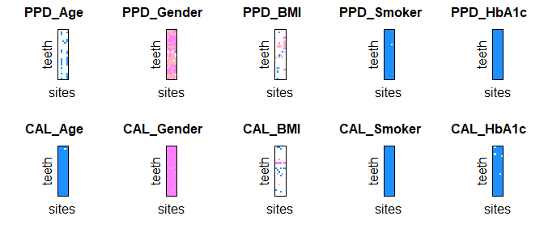

The following Figure (Figure 1 in the main text) shows checkerboard pattern impeding straightforward interpretation.

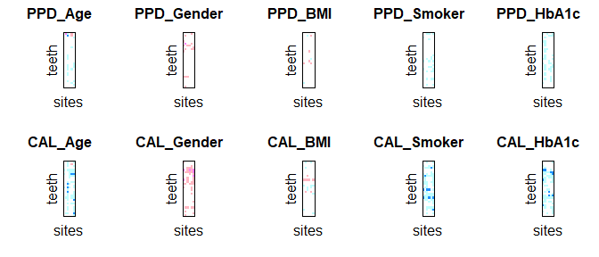